# Databases

HW8 Part 2

Author

# Instructions

Complete all parts of the Exercises section below to earn a Pass for this challenge.

**Requirements for high passing:**

Exercise 1

- Correct SQL to get total number of badges

Exercise 2

- Correct SQL to get total number of badges per name
- Correct SQL to ordered correctly

Exercise 3

- Correct SQL to get display name and date for a chosen type of badge

Exercise 4

- Correct SQL to get display name or id of users who have received the most badges

Exercise 5

- Correct SQL to get display name, user id, reputation, and creationdate, ordered by id

Exercise 6

- Correct SQL to get user id, total number of posts, total upvotes, ordered by id

Exercise 7

- Correct SQL to get user id, total number of comments, total upvotes on comments, ordered by id

Exercise 8

- An appropriate visual of comments and posts.

**Submission:** Click the “Render” button in RStudio to knit a self-contained HTML with all images embedded. Commit and push changes to this file as well as the generated HTML. Push your changes to GitHub by midnight on the deadline. (GitHub classroom automatically creates a pull request for receiving feedback.) Note that your submission is incomplete without a **readable, rendered HTML** in addition to the qmd file.

## Exercises

**Goal:** Analyze Stack Overflow badges and [posts](https://meta.stackexchange.com/questions/2677/database-schema-documentation-for-the-public-data-dump-and-sede) data using SQL queries.

Start at https://data.stackexchange.com/stackoverflow/query/new.

For each exercise, **record the query you used** in the qmd file; you run the query on https://data.stackexchange.com/stackoverflow/query/new to ensure you get the desired result.

**Exercise:** Count the number of total badges that have been given out. Hint: count the number of rows in the relevant table.

> ANSWER: 53771436

```sql
SELECT COUNT(*)
FROM Badges
```

**Exercise:** Find how many times each badge has been awarded, sorted from most awarded to least awarded.

> ANSWER:

```r
ex2<-read.csv("SQL_data/ex2.csv")
head(ex2)
```

```
              Name earnedTimes
1 Popular Question     8310236
2 Notable Question     4153296
3         Informed     3771465
4         Yearling     3641069
5           Editor     3602665
6   Autobiographer     3498345
```

```sql
SELECT Name, COUNT(Name) earnedTimes
FROM Badges
GROUP BY Name
ORDER BY earnedTimes Desc
```

**Exercise:** Find a badge that looks interesting to you. Find all the user **DisplayNames** that have received the badge, along with the date at which they received it.

> ANSWER:

```r
ex3<-read.csv("SQL_data/ex3.csv")
head(ex3)
```

```
     Name                Date     DisplayName
1 Teacher 2012-08-13 11:52:36           dcary
2 Teacher 2012-08-15 13:49:09          dcoles
3 Teacher 2012-08-13 13:02:46         byCoder
4 Teacher 2014-12-06 14:27:47          matuzo
5 Teacher 2012-08-16 15:39:36     mashta gidi
6 Teacher 2012-08-13 14:27:39 Sjoerd van Loon
```

```sql
SELECT Badges.Name, Badges.Date, Users.DisplayName
FROM Badges
LEFT JOIN Users ON Badges.UserId = Users.Id
WHERE Name = 'Teacher' AND Users.DisplayName IS NOT NULL
```

**Exercise:** Show the users who have received the most badges, along with how many they have received.

> ANSWER:

```r
ex4<-read.csv("SQL_data/ex4.csv")
head(ex4)
```

```
  UserId badgesEarned
1  22656        19507
2   6309        10901
3 100297         7975
4 157882         7614
5  29407         6540
6  23354         5858
```

```sql
SELECT UserId, COUNT(UserId) badgesEarned
FROM Badges
GROUP BY UserId
ORDER BY badgesEarned Desc
```

The next few activities analyze user activity. These activities mimic the common workflow of creating datasets in SQL that you analyze in `R`.

**Exercise:** Export a CSV file containing information about each user: `DisplayName, Id, Reputation, and CreationDate`. Because any queries that return more than 50,000 results return a random subset of 50,000 results, include a sort on the user ID variable to ensure that the first 50,000 users are retrieved. Name your file `users.csv`.

> ANSWER:

```r
users_data <- read.csv("SQL_data/users.csv")
head(users_data)
```

```
   DisplayName Id Reputation        CreationDate
1    Community -1          1 2008-07-31 00:00:00
2  Jeff Atwood  1      64009 2008-07-31 14:22:31
3 Geoff Dalgas  2       6176 2008-07-31 14:22:31
4 Jarrod Dixon  3      15807 2008-07-31 14:22:31
5 Joel Spolsky  4      33725 2008-07-31 14:22:31
6 Jon Galloway  5      53165 2008-07-31 14:22:31
```

```sql
SELECT TOP(50000)
DisplayName, Id, Reputation, CreationDate
FROM Users
WHERE Id > -2
ORDER BY Id
```

**Exercise:** Make a table that has each user’s total number of badges, and export this file as a CSV named `badges.csv`. Continue to include a sort on the user ID variable so that this data has information on the same first 50,000 users. *Hint: Start with the badges table, join information from users, and perform some grouped summaries.*

> ANSWER:

```r
badges_data <- read.csv("SQL_data/badges.csv")
head(badges_data)
```

```
  UserId badgesEarned
1     -1            1
2      1          352
3      2          107
4      3          142
5      4          213
6      5          346
```

```sql
SELECT Badges.UserId, COUNT(Badges.UserId)badgesEarned
FROM Badges
JOIN Users ON Badges.UserId = Users.Id
GROUP BY Badges.UserId
ORDER BY Badges.UserId
```

**Exercise:** Make a table that has each user’s total number of posts and total number of upvotes the user has cast, and export this file as a CSV named `posts.csv`. Continue to include a sort on the user ID variable so that this data has information on the same first 50,000 users. *Hint: Start with the posts table, join information from users, and perform some grouped summaries.*

> ANSWER:

```r
posts_data <- read.csv("SQL_data/posts.csv")
head(posts_data)
```

```
  OwnerUserId NumberOfPosts TotalUpVotes
1          -1         20594            0
2           1           141         3265
3           2            11          657
4           3            48         7762
5           4           212          827
6           5           319          758
```

```sql
SELECT
    p.OwnerUserId,
    COUNT(p.OwnerUserId) AS NumberOfPosts,
    MIN(u.UpVotes) AS TotalUpVotes
FROM Posts AS p
JOIN Users AS u ON p.OwnerUserId = u.Id
GROUP BY p.OwnerUserId
ORDER BY p.OwnerUserId
```

**Exercise:** Calculate the number of comments made per user, and the total number of upvotes across all comments made per user (this is the sum of the `Score` variable under the Comments table) and export this as a CSV file named `comments.csv`. Continue to include a sort on the user ID variable so that this data has information on the same first 50,000 users.

> ANSWER:

```r
comments_data <- read.csv("SQL_data/comments.csv")
head(comments_data)
```

```
  UserId NumberOfComments AllUpVotesComments
1     -1           127157              23445
2      1              364               1284
3      2                5                 13
4      3              163                214
5      4              145                324
6      5              141                112
```

```sql
SELECT
    c.UserId,
    COUNT(c.UserId) AS NumberOfComments,
    SUM(c.Score) AS AllUpVotesComments
FROM Comments AS c
JOIN Users AS u ON c.UserId = u.Id
GROUP BY c.UserId
ORDER BY c.UserId
```

**Exercise:** Import these four datasets into `R`. Visualize the relationship between the four datasets. Include at least two visualizations.

Your goal should be to weave together a compelling story about how users on Stackoverflow earn badges through their activity on the site.

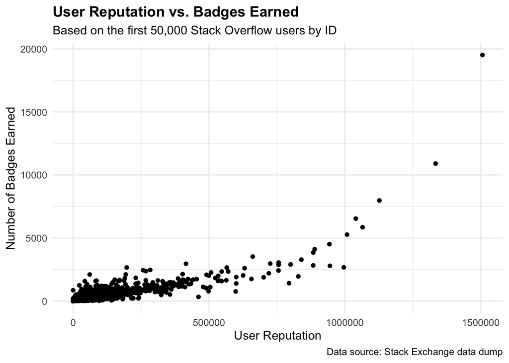

```r
library(dplyr)
library(readr)
library(tidyr)
library(ggplot2)
combined_user_activity <- users_data %>%
  rename(UserId = Id) %>%
  select(UserId, DisplayName, Reputation, CreationDate) %>%
  left_join(badges_data %>% select(UserId, badgesEarned), by = "UserId") %>%
  left_join(posts_data %>% select(OwnerUserId, NumberOfPosts, TotalUpVotes), by = c("UserId" = "OwnerUserId")) %>%
  left_join(comments_data %>% select(UserId, NumberOfComments, AllUpVotesComments), by = "UserId") %>%
  mutate(
    badgesEarned = replace_na(badgesEarned, 0),
    NumberOfPosts = replace_na(NumberOfPosts, 0),
    TotalUpVotes = replace_na(TotalUpVotes, 0),
    NumberOfComments = replace_na(NumberOfComments, 0),
    AllUpVotes = replace_na(AllUpVotesComments, 0)
  )

ggplot(combined_user_activity, aes(x = Reputation, y = badgesEarned)) +
  geom_point() +
  labs(
    title = "User Reputation vs. Badges Earned",
    subtitle = "Based on the first 50,000 Stack Overflow users by ID",
    x = "User Reputation",
    y = "Number of Badges Earned",
    caption = "Data source: Stack Exchange data dump"
  ) +
  theme_minimal(base_size = 12) +
  theme(plot.title = element_text(face = "bold"))
```

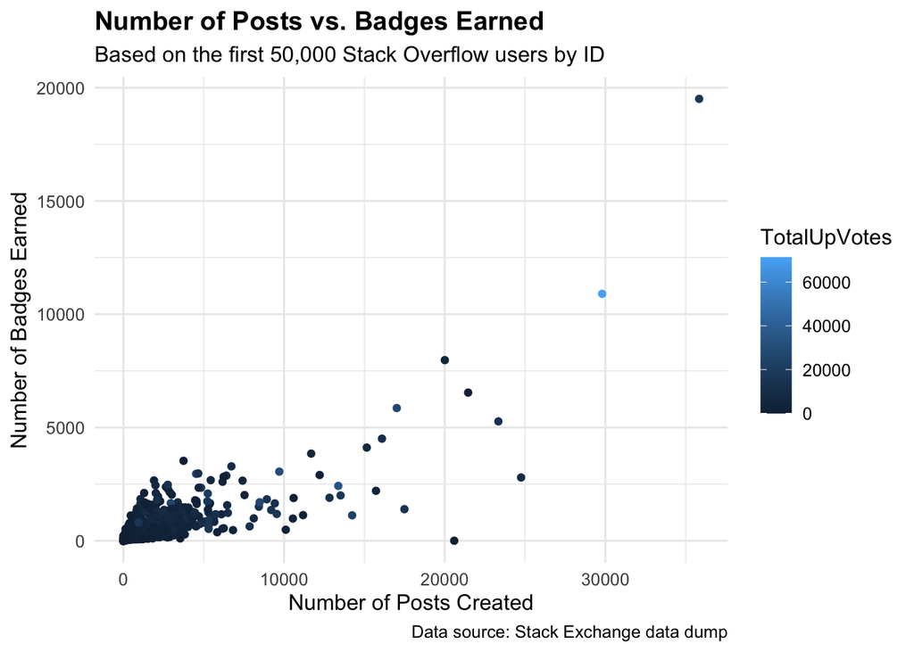

```r
ggplot(combined_user_activity, aes(x = NumberOfPosts, y = badgesEarned, color = TotalUpVotes)) +
  geom_point() +
  labs(
    title = "Number of Posts vs. Badges Earned",
    subtitle = "Based on the first 50,000 Stack Overflow users by ID",
    x = "Number of Posts Created",
    y = "Number of Badges Earned",
    caption = "Data source: Stack Exchange data dump"
  ) +
  theme_minimal(base_size = 12) +
  theme(plot.title = element_text(face = "bold"))
```

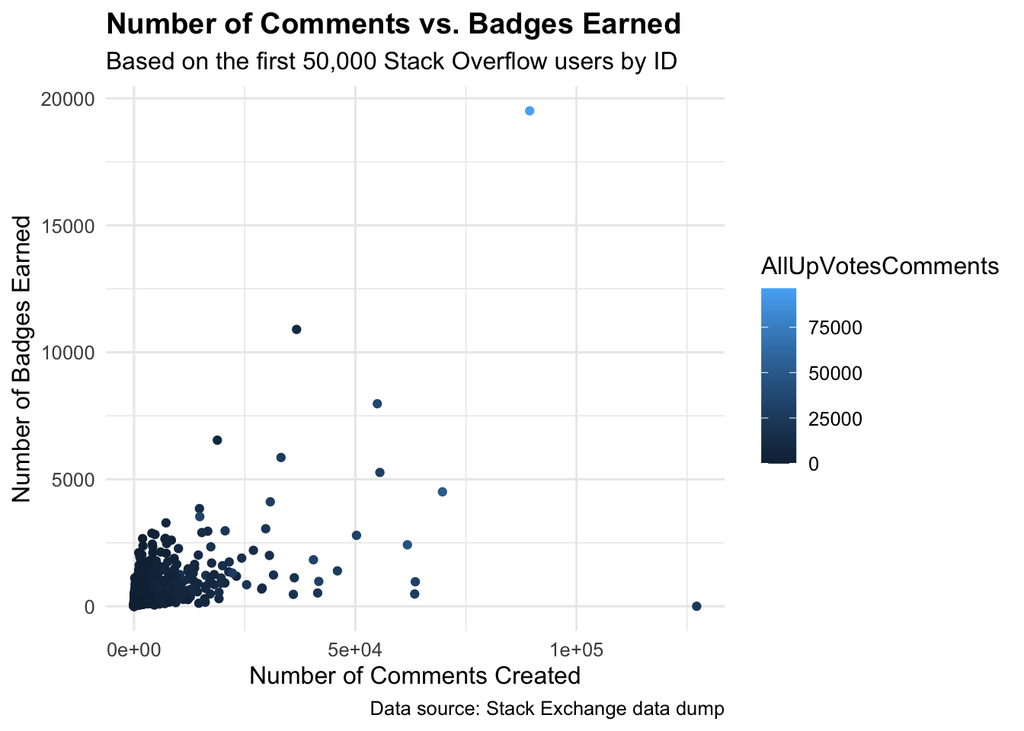

```r
ggplot(combined_user_activity, aes(x = NumberOfComments, y = badgesEarned, color = AllUpVotesComments)) +
  geom_point() +
  labs(
    title = "Number of Comments vs. Badges Earned",
    subtitle = "Based on the first 50,000 Stack Overflow users by ID",
    x = "Number of Comments Created",
    y = "Number of Badges Earned",
    caption = "Data source: Stack Exchange data dump"
  ) +
  theme_minimal(base_size = 12) +
  theme(plot.title = element_text(face = "bold"))
```

# Resources Reflection (required)

What resources did you use to help with this assignment? Please list below. Then write 3-5 sentence reflection on which resources were most helpful in finishing this task.

**Resources:**

1. https://www.w3schools.com/sql/
2. course website
3. https://meta.stackexchange.com/questions/2677/database-schema-documentation-for-the-public-data-dump-and-sede

**Reflection:** Since I’m still not sure about some method in SQL, so I both looked at the course website and searched online. I found the website https://www.w3schools.com/sql/ is very convenient to check the SQL methods with simple examples. The stackexchange website is useful for checking the meaning of variabls.